# Regression Analysis

ChatGPT 4o

2024-11-30

## 1 起源

回归分析（Regression Analysis）是一种用于探讨自变量和因变量之间关系的统计方法。其起源可以追溯到19世纪，由英国统计学家弗朗西斯·高尔顿（Francis Galton）提出并发展起来。回归分析最初用于遗传学研究，用于描述子代与父代之间的关系。如今，回归分析已广泛应用于各种科学和工程领域，以解决预测和因果推断问题。

## 2 原理

回归分析的核心思想是通过建立一个数学模型来描述自变量（或称解释变量）对因变量（或称响应变量）的影响。最简单的形式是线性回归，其中因变量是自变量的线性函数，模型的形式为：

$$Y = \beta_0 + \beta_1 X_1 + \beta_2 X_2 + \cdots + \beta_p X_p +
\epsilon$$

其中，$Y$ 为因变量，$X_1, X_2, \cdots, X_p$ 为自变量，$\beta_0, \beta_1, \cdots, \beta_p$ 为回归系数，$\epsilon$ 为误差项。

回归系数表示自变量对因变量的影响方向和大小。通过最小二乘法（Least Squares Method），可以找到使误差平方和最小的回归系数，从而得到最佳拟合的回归方程。

## 3 适用范围

回归分析适用于以下情况：

- **因变量为连续型**：回归分析用于预测因变量的数值，因变量通常是连续型数据。
- **自变量可以是连续或分类**：自变量可以是连续型、分类型或两者的组合。
- **探讨变量之间的关系**：用于探索多个自变量与因变量之间的线性或非线性关系。

回归分析可以扩展到多种形式，例如线性回归、多项式回归和逻辑回归等。

## 4 应用情境

回归分析在许多实际应用中都有广泛的应用，例如：

- **经济学研究**：用于分析收入与消费之间的关系。
- **医学研究**：用于预测患者的疾病进展，基于年龄、体重、血压等因素。
- **市场营销**：用于预测产品销量，基于广告支出和市场价格。
- **金融分析**：用于预测股票价格，基于各种经济指标。

## 5 优缺点

### 优点

- **解释性强**：回归系数可以直接解释自变量对因变量的影响方向和大小。
- **模型灵活**：可以通过引入非线性项或交互项扩展回归模型，处理复杂关系。
- **广泛应用**：适用于预测和因果推断，广泛应用于各个领域。

### 缺点

- **对线性假设的依赖**：线性回归假设自变量与因变量之间存在线性关系，如果这种关系不成立，模型的准确性会受到影响。
- **对异常值敏感**：回归分析对异常值非常敏感，极端值可能会显著影响模型的结果。
- **多重共线性问题**：自变量之间的高度相关性会导致回归系数不稳定，从而影响模型的解释性。

## 6 在R中的实现及结果解释

在R中，回归分析可以通过`lm()`函数实现。以下是一个实现示例：

```r
# 示例数据：分析年龄与收入之间的关系
set.seed(123)
Age <- rnorm(100, mean = 35, sd = 10)
Income <- 3000 + 500 * Age + rnorm(100, mean = 0, sd = 15000)

# 创建数据框
data <- data.frame(Age = Age, Income = Income)
head(data)
```

```
##        Age    Income
## 1 29.39524  7041.523
## 2 32.69823 23202.368
## 3 50.58708 24593.163
## 4 35.70508 15639.403
## 5 36.29288  6872.160
## 6 52.15065 28399.909
```

```r
# 进行线性回归
reg_model <- lm(Income ~ Age, data = data)

# 输出结果
summary(reg_model)
```

```
##
## Call:
## lm(formula = Income ~ Age, data = data)
##
## Residuals:
##    Min     1Q Median     3Q    Max
## -28610 -10253  -1312   8710  49356
##
## Coefficients:
##             Estimate Std. Error t value Pr(>|t|)
## (Intercept)   4212.7     5937.4   0.710  0.47968
## Age            421.3      160.3   2.628  0.00997 **
## ---
## Signif. codes:  0 '***' 0.001 '**' 0.01 '*' 0.05 '.' 0.1 ' ' 1
##
## Residual standard error: 14560 on 98 degrees of freedom
## Multiple R-squared:  0.06583,    Adjusted R-squared:  0.05629
## F-statistic: 6.906 on 1 and 98 DF,  p-value: 0.009975
```

```r
confint(reg_model, level = 0.95)
```

```
##                  2.5 %     97.5 %
## (Intercept) -7569.8134 15995.2413
## Age           103.1469   739.4383
```

### 结果解释

运行上述代码后，将输出线性回归的结果，主要包括以下内容：

- **回归系数（Estimate）**：表示自变量对因变量的影响大小。截距（Intercept）表示当所有自变量为0时，因变量的估计值，斜率表示自变量变化对因变量的影响。
- **标准误差（Std. Error）**：表示回归系数的不确定性。
- **t值和p值**：用于检验回归系数的显著性。如果p值小于显著性水平（如0.05），则认为该自变量对因变量具有显著影响。
- **R平方（R-squared）**：表示模型对因变量变异的解释程度，取值范围为0到1，值越大表示模型拟合效果越好。
- **(Intercept) = 4212.7**：截距的估计值为4212.7。
- **Age = 421.3**：年龄对收入的影响为正，p<0.05，表示显著,平均而言，年龄每增长1岁，收入增加421.3元。

### 结果的可视化

可以使用R中的`ggplot2`包对回归结果进行可视化，以展示自变量与因变量之间的关系及回归拟合线。

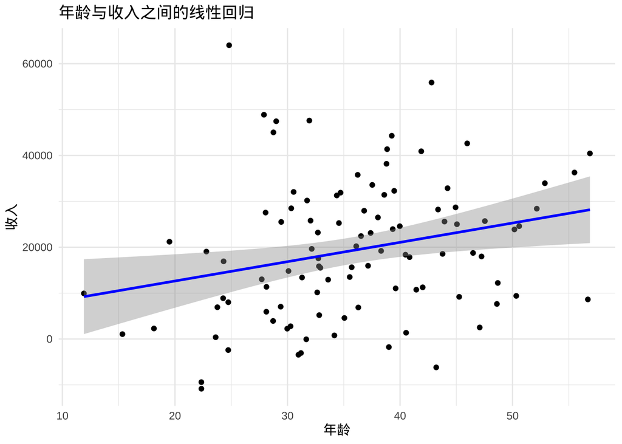

```r
# 加载ggplot2包
library(ggplot2)

# 绘制散点图并添加回归线
ggplot(data, aes(x = Age, y = Income)) +
  geom_point() +
  geom_smooth(method = "lm", se = TRUE, color = "blue") +
  labs(title = "年龄与收入之间的线性回归", x = "年龄", y = "收入") +
  theme_minimal()
```

上述代码将绘制一个散点图，并添加一条回归拟合线，通过图形可以更直观地观察到年龄对收入的影响及其趋势。

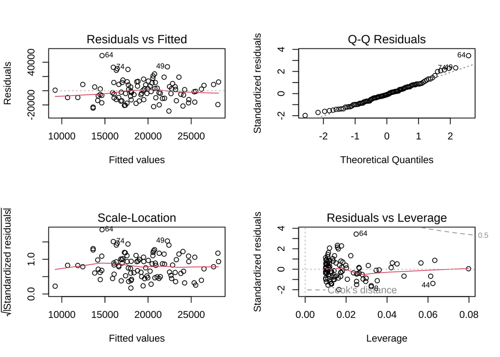

```r
# 绘制回归诊断图
par(mfrow = c(2, 2))  # 在同一屏幕上显示四个图
plot(reg_model)
```

### 1. Residuals vs Fitted Plot

**残差与拟合值图**用于检查线性关系假设。横轴为拟合值，纵轴为残差。

- **目的**：检查线性假设是否合理，以及残差是否呈现随机分布。
- **理想情况**：数据点应围绕零线随机分布，且没有明显的模式。
- **如果发现模式**：如存在曲线形态或其他明显的趋势，可能表明模型中缺少某些**非线性项**。

### 2. Normal Q-Q Plot

**正态 Q-Q 图**用于检查残差的正态性假设。

- **目的**：验证残差是否符合正态分布。
- **理想情况**：点应沿着对角线呈一条直线分布。
- **偏离直线的情况**：如果点明显偏离对角线，表明残差**不是正态分布**，可能需要对数据进行转换。

### 3. Scale-Location Plot (or Spread-Location Plot)

**尺度-位置图**（也称为方差齐性图）用于检查残差的等方差性假设。

- **目的**：检验残差的方差是否均匀分布。
- **理想情况**：数据点应随机分布在一条水平线上，且没有明显的模式。
- **如果残差呈现漏斗形**：这表明存在**异方差性**，可能需要对响应变量进行变换或使用稳健回归方法。

### 4. Residuals vs Leverage Plot

**残差与杠杆值图**用于识别高杠杆点（即对模型影响大的数据点）以及异常值。

## 7 小结

- 回归分析用于探索自变量与因变量之间的关系，通过建立回归方程来描述这种关系。
- 适用于因变量为连续型的数据，自变量可以是连续型或分类型，用于预测和因果推断。
- 具有解释性强、模型灵活等优点，但对线性假设、异常值和多重共线性较为敏感。
- 可以通过R中的`lm()`函数实现线性回归，并结合可视化更直观地展示结果。
- 在经济学、医学、市场营销、金融等领域有广泛的应用价值。